# Assessing Canada’s Drug Shortage Problem

[figure not shown]

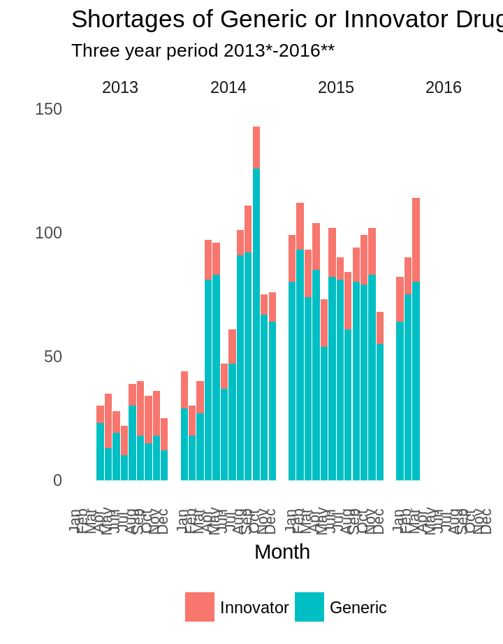

[figure not shown]

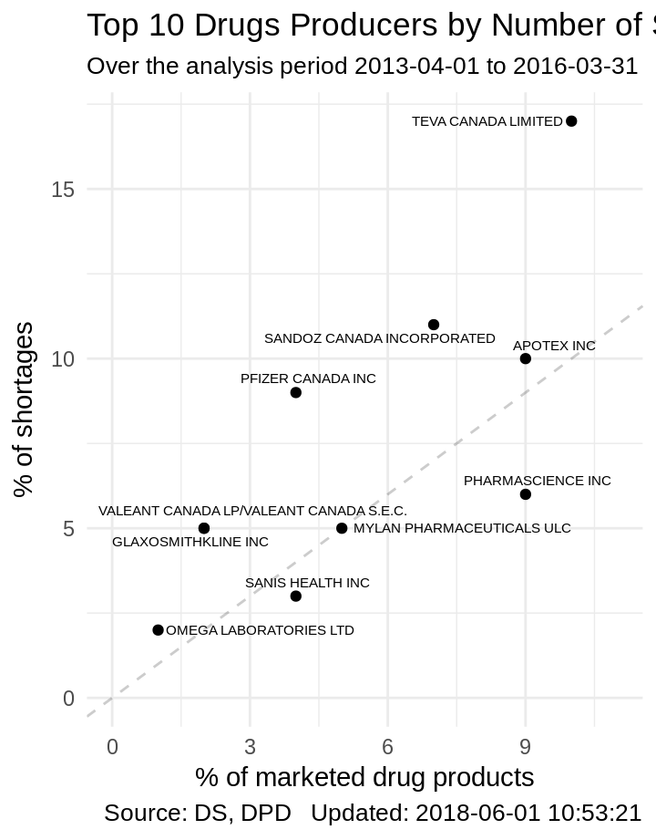

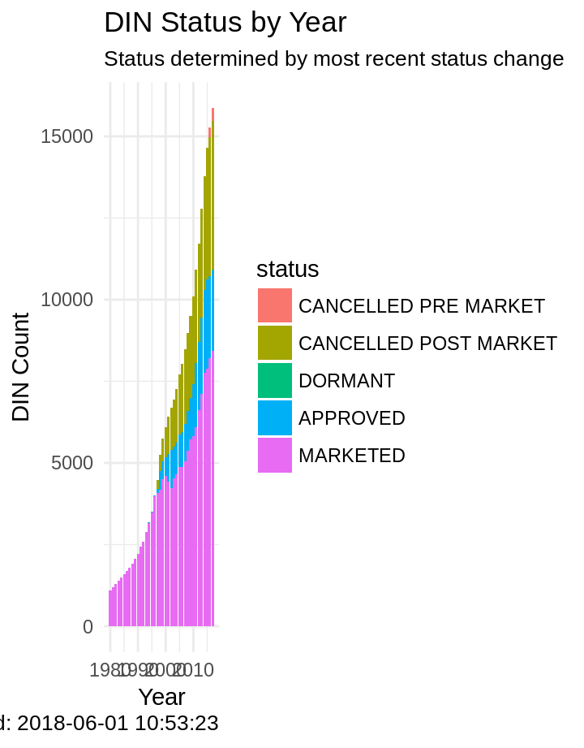

[figure not shown]

[figure not shown]

[figure not shown]

[figure not shown]

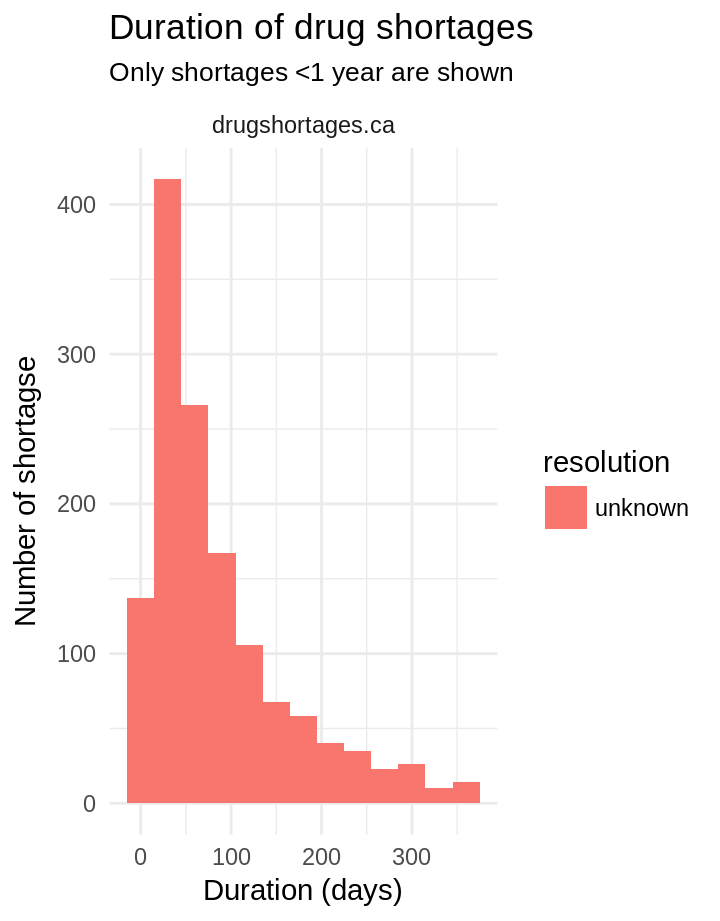

[figure not shown]

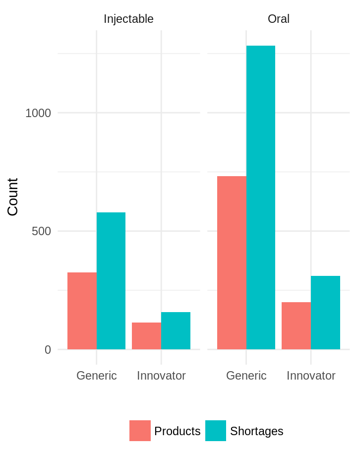

# Drug Shortages

### Shortage Datasets

We have two sources of data on drug shortages:

#### drugshortages.ca

- Active until March, 2017
- Voluntary reporting
- We manually collected data from this database from 2013-04-01 through 2016-03-31 (`drugshortages.ca-manual.csv`)
- We also obtained exports of this database as of various dates (`drughsortages.ca-export.csv`)

#### drugshortagescanada.ca

- Active from March 2017 to present
- Mandatory reporting
- Exports provided on demand via online search
- Note: The *anticipated shortage start date* is used if the start date is blank. If a shortage for the same DIN and start date appears in both datasets it is included once.

### Ingredient Groups

Ingredient Groups are taken from the [Drug Product Database](https://www.canada.ca/en/health-canada/services/drugs-health-products/drug-products/drug-product-database/terminology.html) active ingredient group number which identifies the unique groups of active ingredients(s) regardless of strength. This is explained in more detail on the “Drug Products” tab.

### Figure 1 - Drug Shortages Per Month

[figure not shown]

### Figure 3 - Shortages by Innovator Status

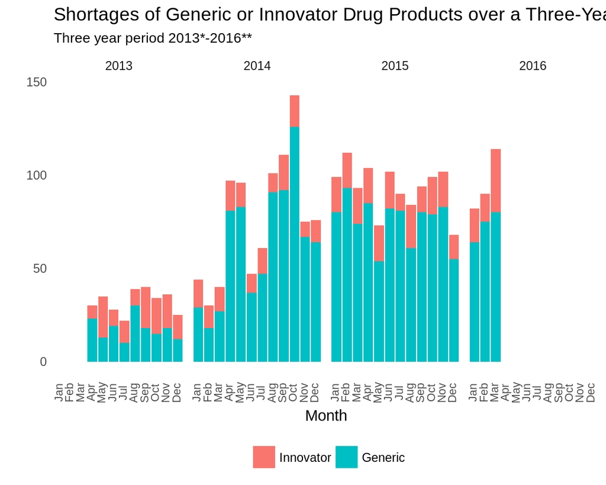

### Figure 5 - Shortages by Ingredient Group

[figure not shown]

### Figure 9: Top 10 Drugs MFRs by Shortages

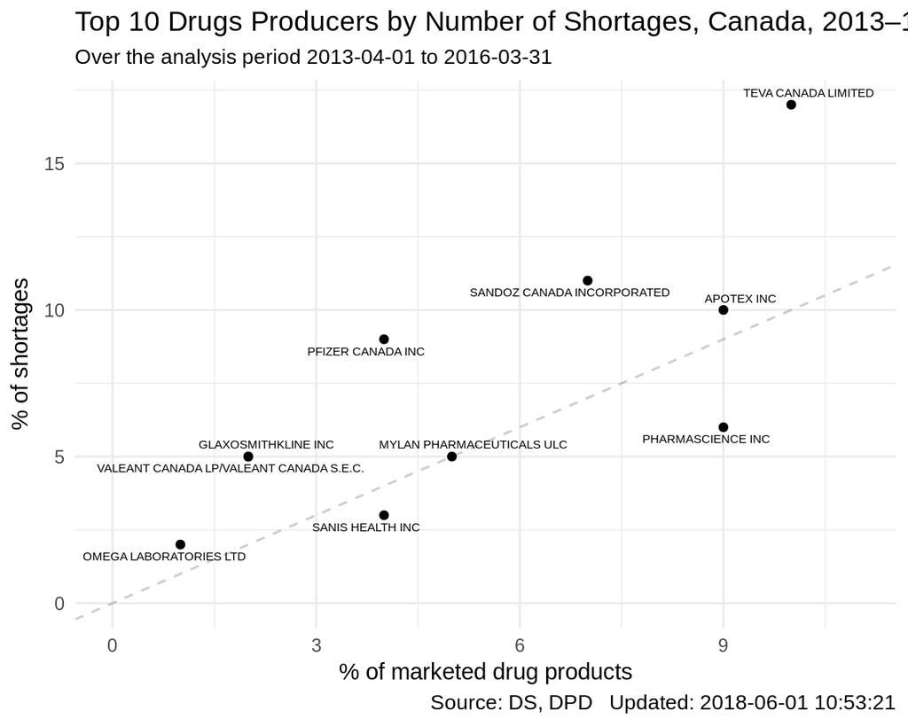

### Table 3 - Oral Drug shortages by Company

| Company Name | # of Products (DIN) | # of Shortages | % of Total Shortages |
| --- | --- | --- | --- |
| Teva Canada Limited | 223 | 323 | 20.25 |
| Apotex Inc. | 220 | 241 | 15.11 |
| Pharmascience Inc. | 103 | 134 | 8.40 |
| Pfizer Canada Inc. | 77 | 103 | 6.46 |
| Mylan Pharmaceuticals ULC | 91 | 99 | 6.21 |
| Valeant Canada | 87 | 90 | 5.64 |
| Sanis Health Inc. | 74 | 81 | 5.08 |
| GlaxoSmithKline Inc. | 32 | 70 | 4.39 |
| Sandoz Canada Inc. | 56 | 70 | 4.39 |
| JAMP PHARMA CORPORATION | 26 | 27 | 1.69 |
| AstraZeneca Canada Inc. | 19 | 26 | 1.63 |
| LABORATOIRE RIVA INC | 25 | 26 | 1.63 |
| LABORATOIRES TRIANON INC | 23 | 23 | 1.44 |
| Novartis Canada Inc. | 17 | 22 | 1.38 |
| Paladin Labs Inc. | 19 | 22 | 1.38 |
| Sanofi Canada | 17 | 20 | 1.25 |
| BGP Pharma ULC | 16 | 17 | 1.07 |
| Bristol-Myers Squibb Canada | 13 | 15 | 0.94 |
| Merck Canada Inc. | 9 | 15 | 0.94 |
| TOTAL | 1147 | 1424 | 89.28 |

### Table 4 - Injectable Drug shortages by Company

| Company Name | # of Products (DIN) | # of Shortages | % of Total Shortages |
| --- | --- | --- | --- |
| Hospira Healthcare Corporation | 96 | 192 | 26.02 |
| Sandoz Canada Inc. | 118 | 174 | 23.58 |
| Teva Canada Limited | 35 | 61 | 8.27 |
| Pfizer Canada Inc. | 34 | 47 | 6.37 |
| Omega Laboratories Ltd. | 27 | 37 | 5.01 |
| Fresenius Kabi | 20 | 31 | 4.20 |
| Baxter Corporation | 23 | 24 | 3.25 |
| GlaxoSmithKline Inc. | 11 | 21 | 2.85 |
| Apotex Inc. | 11 | 13 | 1.76 |
| ASPEN PHARMA TRADING LIMITED | 5 | 13 | 1.76 |
| Mylan Pharmaceuticals ULC | 11 | 11 | 1.49 |
| Sanofi Canada | 7 | 9 | 1.22 |
| Bristol-Myers Squibb Canada | 6 | 8 | 1.08 |
| Hoffmann-La Roche Limited | 8 | 8 | 1.08 |
| STERIMAX INC | 5 | 8 | 1.08 |
| Merck Canada Inc. | 3 | 7 | 0.95 |
| TOTAL | 420 | 664 | 89.97 |

# Drug Products

### Background

The Health Canada [Drug Product Database](https://www.canada.ca/en/health-canada/services/drugs-health-products/drug-products/drug-product-database.html) provides historical records of drug products (and provides [extracts](https://www.canada.ca/en/health-canada/services/drugs-health-products/drug-products/drug-product-database/what-data-extract-drug-product-database.html))

For the following charts, we only consider prescription drugs for humans.

The DPD contains records tracking the change in a DINs status over time (in the `QRYM_STATUS`) table. Drug products are given a status of either: `APPROVED`, `MARKETED`, `CANCELLED POST-MARKET`, `CANCELLED PRE-MARKET`, or `DORMANT`.

The following chart shows, for each year, the number of drug products categorized by their status in that year. Drug product status in a year is taken from the most recent QRYM_STATUS entry to the year.

### DIN Status

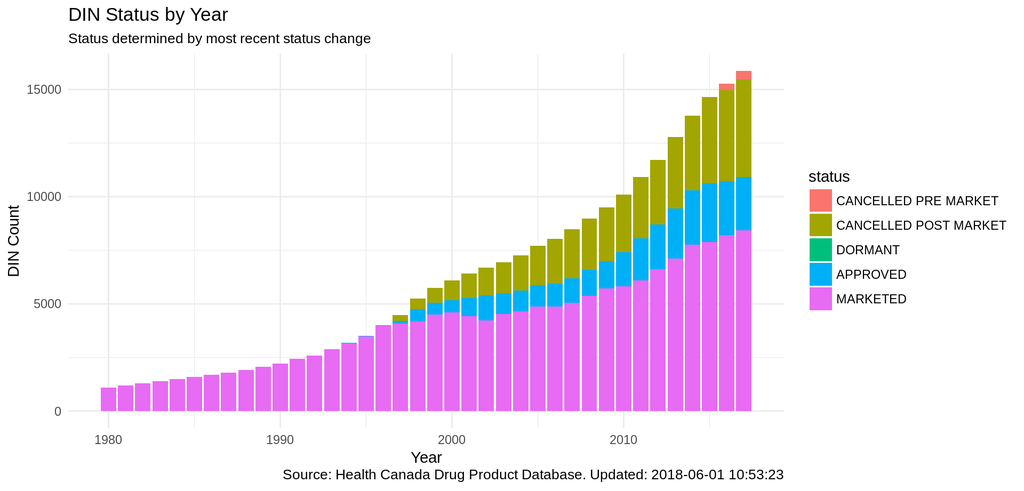

### Figure 8: Market Share By MFR

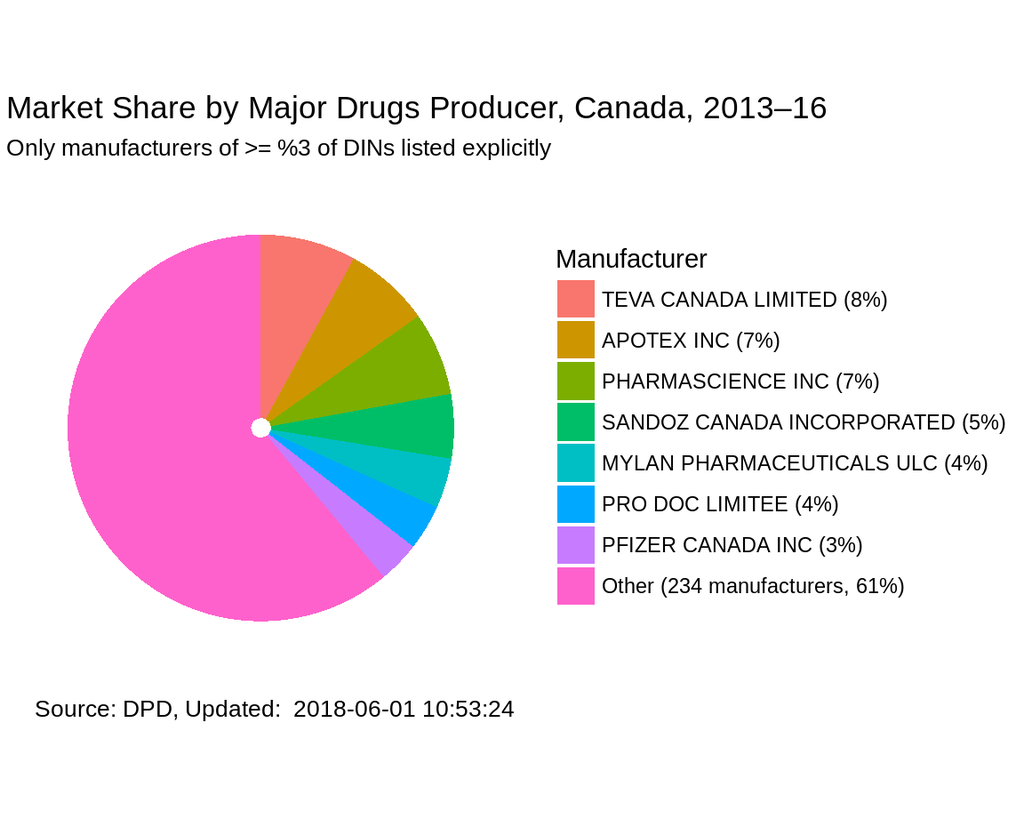

# Innovator vs. Generics

### Background

In this section we look at innovator vs. generic drug products historically. To determine whether a drug product is an innovator or generic we make the assumption innovator drug products are always created before generic drug products. Therefore in a group of drug products with the same active ingredients, the earliest manufacturer is the innovator and all their drug products in the group are marked as such. All other drug products, are marked as generic.

[From the DPD page on Terminology](https://www.canada.ca/en/health-canada/services/drugs-health-products/drug-products/drug-product-database/terminology.html):

“The AIG [Active Ingredient Group] number is a 10 digit number that identifies products that have the same active ingredient(s) and ingredient strength(s). The AIG is comprised of three portions:

- the first portion (2 digits) identifies the number of active ingredients
- the second portion(5 digits) identifies the unique groups of active ingredients(s);
- the last portion (3 digits) identifies the active ingredient group strength. The strength group has a tolerance of -2% to +10%."

Innovator/Generic status is determined within groups determined by the second portion of the AIG only so that drug strength is ignored.

The following chart shows only the active drug products (`MARKETED`) over time.

### Figure 10: Drug Products (DINs) by Year

[figure not shown]

# Supplementary Figures

### Shortages by Reasons

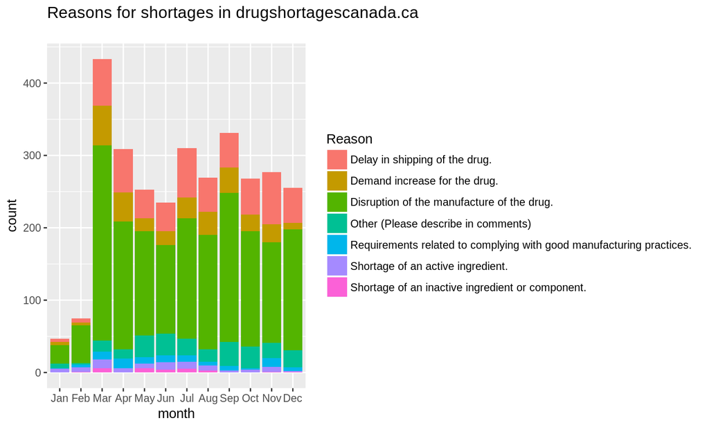

### Shortages by Duration

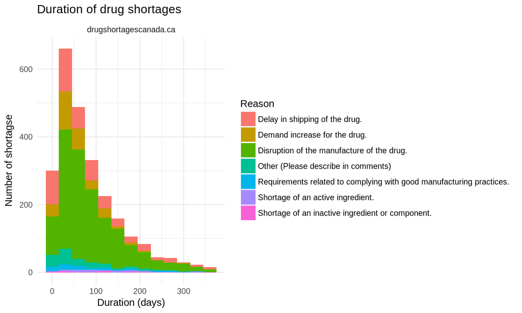

### Shortages by Duration/Resolution

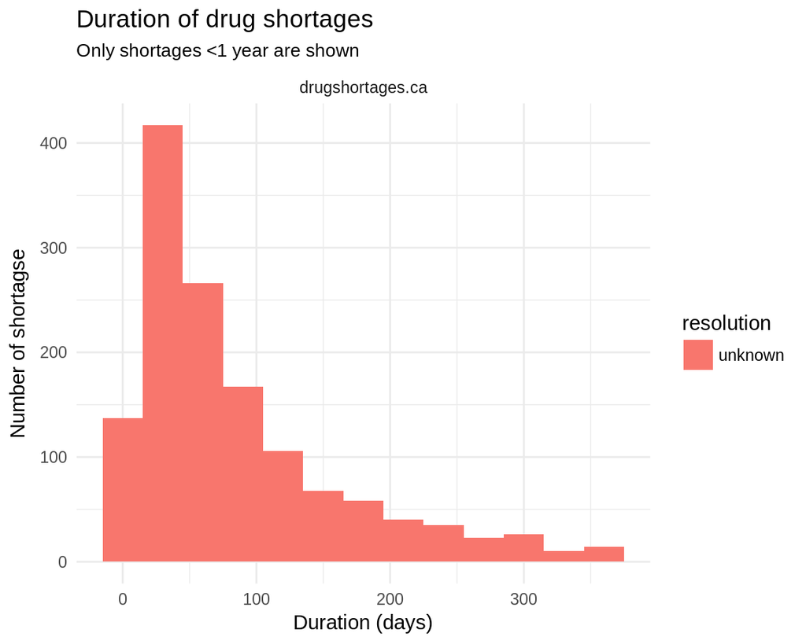

### Shortages Per Manufacturer

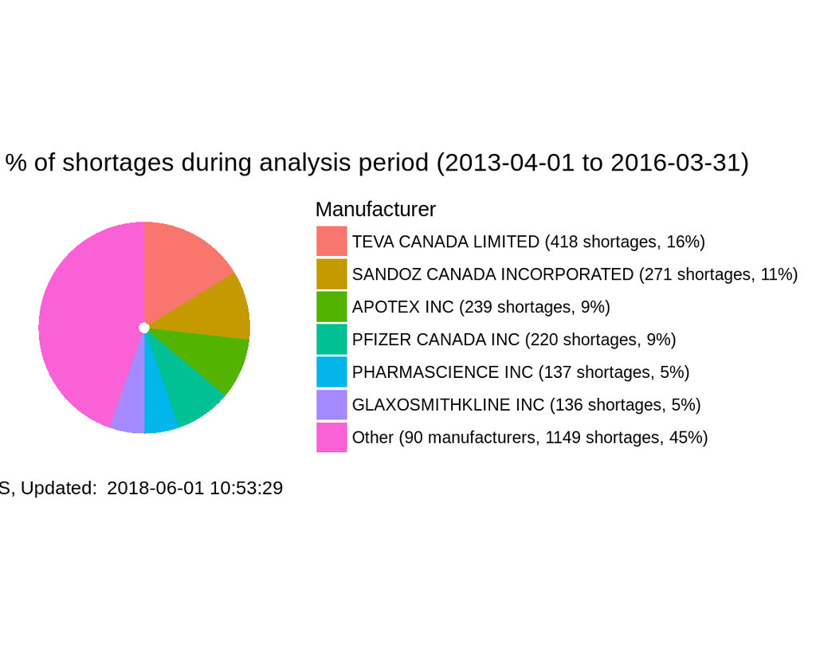

### Shortages by Route

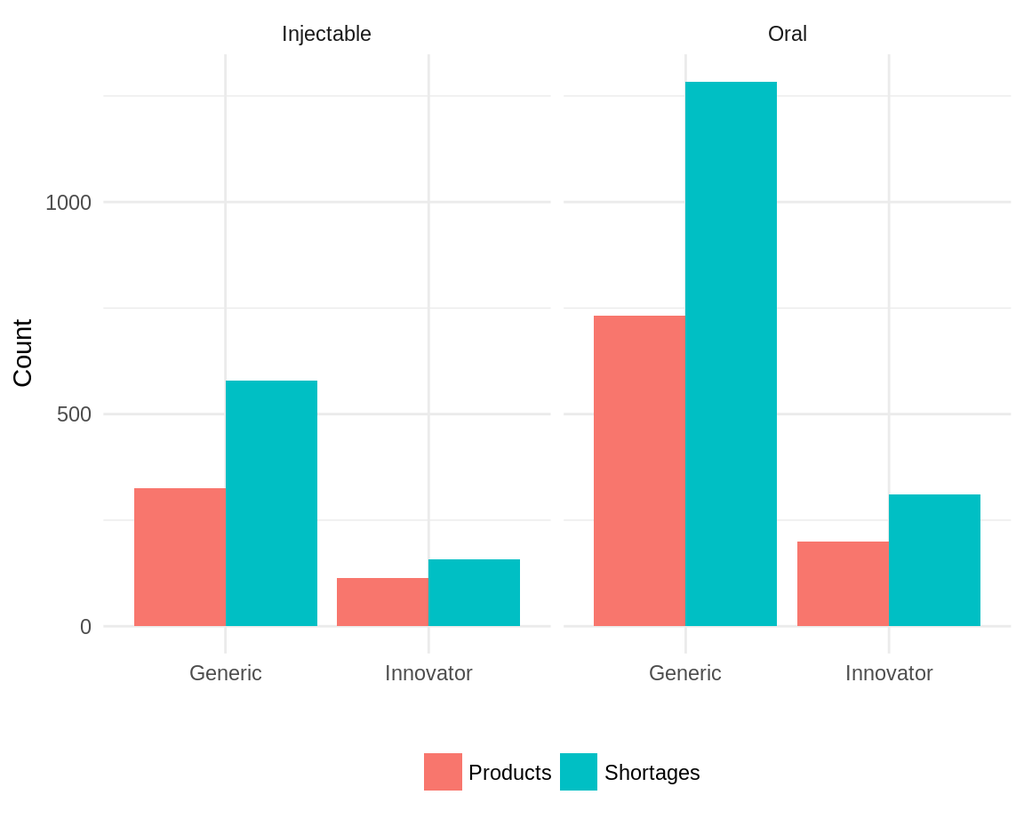

````r
---
title: "Assessing Canada’s Drug Shortage Problem"
#author: "Jon Pipitone"
output:
  flexdashboard::flex_dashboard:
    source_code: embed
---

```{r setup}
knitr::opts_chunk$set(echo = FALSE)
library(tidyverse, warn.conflicts = FALSE)
library(ggrepel)
library(lubridate)

# Terminology
# DPD = Drug Product Database
# DSC = drugshortagescanada.ca - the current, mandatory reporting shortage databsae
# DS  = drugshortages.ca - the previous, voluntary reporting shortage datbase

# Settings (note: some figures have settings in their chunks)
DSC_CSV = 'data/drugshortagescanada.ca-2017-12-31.csv'
DS_MANUAL_CSV = 'data/drugshortages.ca-manual.csv'
DS_EXPORT_CSV = 'data/drugshortages.ca-export.csv'
ANALYSIS_PERIOD_START = as.Date("2013-04-01")   # start of manual collection period
ANALYSIS_PERIOD_END   = as.Date("2016-03-31")   # end of manual collection period

DPD_YEAR_START = ymd('1980-01-01') # earliest year to look at in the DPD
DPD_YEAR_END = ymd('2017-01-01')   # latest year to look at in the DPD

# set to TRUE to attempt to download the latest DPD dataset
DPD_DOWNLOAD = FALSE

# URL for the drug product database files
DPD_URL_BASE='http://www.hc-sc.gc.ca/dhp-mps/alt_formats/zip/prodpharma/databasdon/'
```

```{r load-drug-shortage-data}
# New Drug Shortages database
drugshortagescanada_ca_raw = read_csv(DSC_CSV, col_types=cols(
  DIN=col_character(),
  `Shortage Start Date` = col_date(),
  `Anticipated Shortage Start Date` = col_date(),
  `Actual Shortage End Date` = col_date(),
  `Estimated Shortage End Date` = col_date()
  ))
drugshortagescanada_ca = drugshortagescanada_ca_raw %>%
  mutate(start_date = if_else(is.na(`Shortage Start Date`),
                              `Anticipated Shortage Start Date`, `Shortage Start Date`),
         end_date = if_else(is.na(`Actual Shortage End Date`),
                              `Estimated Shortage End Date`, `Actual Shortage End Date`),
         source = 'drugshortagescanada.ca',
         resolution = 'Current') %>%
  select(DIN, start_date, end_date, source, Reason, resolution)


# Manually collected drugshortages.ca data collected during the analysis period
drugshortages_ca_manual_raw = read_csv(DS_MANUAL_CSV)
drugshortages_ca_manual = drugshortages_ca_manual_raw %>%
  transmute(
    DIN = din,
    start_date = as.Date(start_date),
    end_date = as.Date(est_resupply_date),
    source = 'drugshortages.ca-manual',
    Reason = 'Unknown',
    resolution = outcome,
    resolution = 'unknown'
  )

# Export of the drugshortages.ca database obtained from the maintainer
drugshortages_ca_export_raw = read_csv(DS_EXPORT_CSV)
drugshortages_ca_export = drugshortages_ca_export_raw %>%
  transmute(
    DIN = str_pad(DIN, 8, pad = "0"),
    start_date = as.Date(`Start Date`),
    end_date = as.Date(`Estimated Resupply Date`),
    source = "drugshortages.ca-export",
    Reason = `Reason for Shortage`,
    resolution = if_else(is.na(Discontinued), Status, Discontinued))
```

```{r merge-shortage-datasets}
# merge the drugshortages.ca datasets
# We will only include data from the Export after the end of the analysis period
drugshortages_ca = drugshortages_ca_export %>%
  filter(start_date > ANALYSIS_PERIOD_END) %>%
  bind_rows(drugshortages_ca_manual) %>%
  group_by(DIN, start_date) %>%                   # remove duplicates
  summarize(
    end_date = first(end_date),
    source = 'drugshortages.ca',
    Reason = first(Reason),
    resolution = first(resolution)) %>%
  ungroup()

# merge the datasets
shortages = bind_rows(drugshortagescanada_ca, drugshortages_ca) %>%
  group_by(DIN, start_date) %>%
  summarize(source = if_else(n() == 1, paste(source, collapse=" "), 'both')) %>%
  ungroup()
```

```{r load-dpd-dataset}
# Load the Health Canada Drug Product Database
DPD_DATA_DIR = 'data/dpd/'

if(DPD_DOWNLOAD) {
  for (f in c('allfiles.zip', 'allfiles_ia.zip', 'allfiles_ap.zip', 'allfiles_dr.zip')) {
    destfile = paste0(DPD_DATA_DIR, f)
    download.file(paste0(DPD_URL_BASE, f), destfile)
    unzip(destfile, exdir = DPD_DATA_DIR)
  }
}

tables = list(
  comp = c("DRUG_CODE","MFR_CODE","COMPANY_CODE","COMPANY_NAME","COMPANY_TYPE",
           "ADDRESS_MAILING_FLAG","ADDRESS_BILLING_FLAG",
           "ADDRESS_NOTIFICATION_FLAG","ADDRESS_OTHER","SUITE_NUMBER",
           "STREET_NAME","CITY_NAME","PROVINCE","COUNTRY","POSTAL_CODE",
           "POST_OFFICE_BOX","PROVINCE_F","COUNTRY_F"),
  form = c("DRUG_CODE","PHARM_FORM_CODE","PHARMACEUTICAL_FORM",
           "PHARMACEUTICAL_FORM_F"),
  ingred = c("DRUG_CODE","ACTIVE_INGREDIENT_CODE","INGREDIENT",
             "INGREDIENT_SUPPLIED_IND","STRENGTH","STRENGTH_UNIT",
             "STRENGTH_TYPE","DOSAGE_VALUE","BASE","DOSAGE_UNIT","NOTES",
             "INGREDIENT_F","STRENGTH_UNIT_F","STRENGTH_TYPE_F","DOSAGE_UNIT_F"),
  package = c("DRUG_CODE","UPC","PACKAGE_SIZE_UNIT","PACKAGE_TYPE",
              "PACKAGE_SIZE","PRODUCT_INFORMATION","PACKAGE_SIZE_UNIT_F",
              "PACKAGE_TYPE_F"),
  pharm = c("DRUG_CODE","PHARMACEUTICAL_STD"),
  drug = c("DRUG_CODE","PRODUCT_CATEGORIZATION","CLASS",
           "DRUG_IDENTIFICATION_NUMBER","BRAND_NAME","DESCRIPTOR",
           "PEDIATRIC_FLAG","ACCESSION_NUMBER","NUMBER_OF_AIS",
           "LAST_UPDATE_DATE","AI_GROUP_NO","CLASS_F","BRAND_NAME_F",
           "DESCRIPTOR_F"),
  route = c("DRUG_CODE","ROUTE_OF_ADMINISTRATION_CODE",
            "ROUTE_OF_ADMINISTRATION","ROUTE_OF_ADMINISTRATION_F"),
  sched = c("DRUG_CODE","SCHEDULE","SCHEDULE_F"),
  status = c("DRUG_CODE","CURRENT_STATUS_FLAG","STATUS","HISTORY_DATE",
             "STATUS_F","LOT_NUMBER","EXPIRATION_DATE"),
  ther = c("DRUG_CODE","TC_ATC_NUMBER","TC_ATC","TC_AHFS_NUMBER","TC_AHFS",
           "TC_ATC_F","TC_AHFS_F"),
  vet = c("DRUG_CODE","VET_SPECIES","VET_SUB_SPECIES","VET_SPECIES_F")
)

for (table_name in names(tables)) {
  headers = tables[[table_name]]
  # create new variables based on the DPD table names (e.g. dpd_vet) and load in the
  # data from the corresponding files (active, inactive, etc..) and merge them
  assign(paste0('dpd_', table_name),
    dir(DPD_DATA_DIR, pattern = paste0(table_name, '.*.txt$'), full.names = TRUE) %>%
      keep(function(x) file.size(x) > 0) %>%
      map(read_csv,
          col_names = headers,
          locale = locale('en', date_format = '%d-%b-%Y'),
          col_types = map(headers,  function (x) # guess base on name
            case_when(
              endsWith(x, '_DATE') ~ 'D',
              x == 'DRUG_CODE' ~ 'i',
              TRUE ~ 'c')) %>%
          setNames(headers), progress = FALSE) %>%
      reduce(rbind)
  )
}
````